# Globale Ungleichheit — Was können wir aus Daten lernen?

Eine Vorschau auf das, was du am Ende dieses Seminars selbst bauen kannst

Seminar: Globale Ungleichheit

Wintersemester 2025/26

```r
library(tidyverse)
library(here)
library(knitr)

# Optional: von der Konsole rendern (nicht aus diesem Chunk ausführen).
# `here()` zeigt auf den Ordner der *aktiven* .Rproj-Datei — Pfade nicht doppeln:
#
# • session_01.Rproj geöffnet:
#     rmarkdown::render(here::here("demo_endgame.Rmd"))
# • Repo-Stamm / Shell-CWD = Intro_to_R_Seminar:
#     rmarkdown::render(here::here("sessions", "session_01", "demo_endgame.Rmd"))
#
# Fehler ".../session_01/sessions/session_01/..."? Zweite Variante mit geöffnetem session_01.Rproj benutzt.
```

```r
# Rohdaten einlesen
owid_roh <- read_csv(
  here("data", "owid_data.csv"),
  show_col_types = FALSE
)

# world_region ist nur für ~140 Länder befüllt → Referenztabelle, dann Join
region_lookup <- owid_roh |>
  filter(!is.na(world_region)) |>
  distinct(country, world_region)

# inner_join: nur echte Länder, OWID-Aggregate ("World", …) fallen weg
owid_laender <- owid_roh |>
  select(-world_region) |>
  inner_join(region_lookup, by = "country")

owid_laender <- owid_laender |>
  mutate(
    bip_pro_kopf = gdp / population,
    region = world_region
  ) |>
  filter(year >= 1990, year <= 2020)

# Zwischenstand speichern (so arbeitest du später mit Skripten + source())
saveRDS(owid_laender, here("data", "owid_bereinigt.rds"))

# Ab hier: ein Objekt `owid` für alle Grafiken
owid <- owid_laender
```

## Was ist das hier?

Dieses Dokument zeigt, was du am Ende dieses Semesters selbst erstellen kannst — in R, mit echten Daten, in einem reproduzierbaren Dokument wie diesem.

Es verwendet Daten von [Our World in Data](https://ourworldindata.org): einen Datensatz mit fast 200 Ländern und Messungen von den 1990er Jahren bis heute. Einkommen, Ungleichheit, Lebenserwartung, Kindersterblichkeit, CO₂-Emissionen — all das ist darin enthalten.

**Der Code für jede Grafik und Tabelle ist in diesem Dokument versteckt.** Du kannst ihn jederzeit aufklappen, indem du auf *Code* klickst — du siehst dann den echten R-Code (nicht nur `source()`). Am Ende des Semesters wirst du verstehen, was jede Zeile tut — und deinen eigenen Bericht damit bauen können.

## 1 · Wie ungleich ist die Welt — und wo?

Der Gini-Koeffizient misst Einkommensungleichheit auf einer Skala von 0 (jede Person hat dasselbe Einkommen) bis 1 (eine Person hat alles). Ein Wert über 0,45 gilt als hoch; die meisten Industrieländer liegen zwischen 0,25 und 0,35.

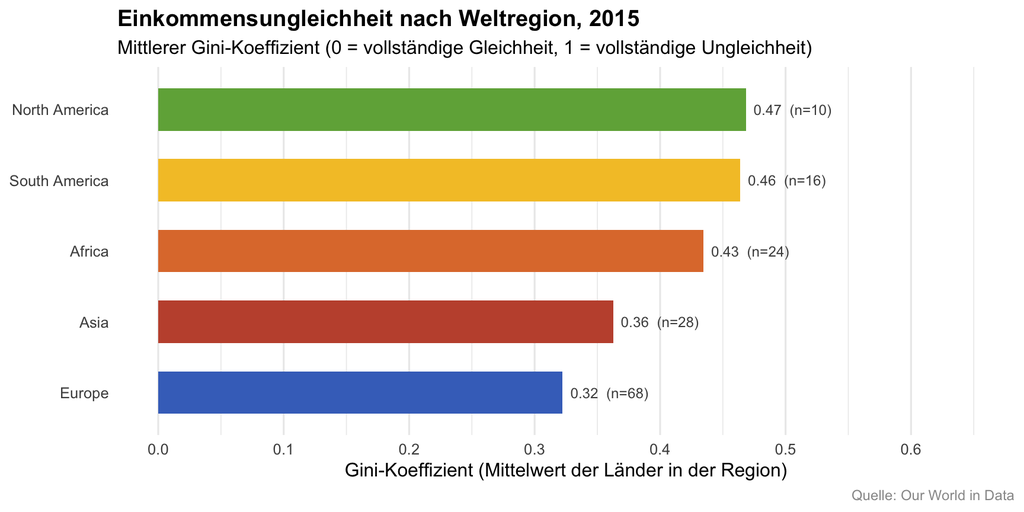

```r
# Benanntes Vektor: Schlüssel = exakter Wert in `region`/`fill`/`color`,
# Wert = Hex-Farbe. scale_*_manual(values = region_farben) ordnet jeder Region dieselbe Farbe in allen Grafiken.
region_farben <- c(
  "Africa"        = "#E07B39",
  "Asia"          = "#C3533A",
  "Europe"        = "#4472C4",
  "North America" = "#70AD47",
  "Oceania"       = "#9B59B6",
  "South America" = "#F4C430"
)

gini_region_2015 <- owid |>
  filter(year == 2015, !is.na(gini)) |>
  group_by(region) |>
  summarise(
    gini_mittel = mean(gini, na.rm = TRUE),
    n_laender = n()
  ) |>
  mutate(region = fct_reorder(region, gini_mittel))

grafik_gini_region <- ggplot(
  gini_region_2015,
  aes(x = gini_mittel, y = region, fill = region)
) +
  geom_col(show.legend = FALSE, width = 0.6) +
  geom_text(
    aes(label = paste0(round(gini_mittel, 2), "  (n=", n_laender, ")")),
    hjust = -0.1,
    size = 3.2,
    color = "grey30"
  ) +
  scale_fill_manual(values = region_farben) +
  scale_x_continuous(
    limits = c(0, 0.65),
    breaks = seq(0, 0.6, 0.1),
    labels = scales::number_format(accuracy = 0.1)
  ) +
  labs(
    title = "Einkommensungleichheit nach Weltregion, 2015",
    subtitle = "Mittlerer Gini-Koeffizient (0 = vollständige Gleichheit, 1 = vollständige Ungleichheit)",
    x = "Gini-Koeffizient (Mittelwert der Länder in der Region)",
    y = NULL,
    caption = "Quelle: Our World in Data"
  ) +
  theme_minimal(base_size = 12) +
  theme(
    plot.title = element_text(face = "bold"),
    panel.grid.major.y = element_blank(),
    plot.caption = element_text(color = "grey60", size = 9)
  )

grafik_gini_region
```

Lateinamerika und Afrika weisen im Durchschnitt deutlich höhere Ungleichheit auf als Europa — aber innerhalb jeder Region gibt es erhebliche Unterschiede. Diese Variation ist der Ausgangspunkt für viele Analysen im Seminar.

## 2 · Wer sind die ungleichsten Länder der Welt?

```r
tabelle_gini <- owid |>
  filter(year == 2015, !is.na(gini), !is.na(region)) |>
  select(Land = country, Region = region, Gini = gini) |>
  arrange(desc(Gini))

tabelle_gini_top10 <- tabelle_gini |>
  slice_head(n = 10) |>
  mutate(Rang = row_number(), .before = Land)

tabelle_gini_bottom10 <- tabelle_gini |>
  slice_tail(n = 10) |>
  mutate(Rang = (nrow(tabelle_gini) - 9):nrow(tabelle_gini), .before = Land)

kable(
  tabelle_gini_top10,
  digits  = 3,
  caption = "Tabelle 1a: Zehn Länder mit der höchsten Einkommensungleichheit, 2015",
  col.names = c("Rang", "Land", "Region", "Gini")
)
```

| Rang | Land | Region | Gini |
| --- | --- | --- | --- |
| 1 | Namibia | Africa | 0.591 |
| 2 | Namibia | Africa | 0.591 |
| 3 | Zambia | Africa | 0.571 |
| 4 | Zambia | Africa | 0.571 |
| 5 | Botswana | Africa | 0.533 |
| 6 | Botswana | Africa | 0.533 |
| 7 | Brazil | South America | 0.519 |
| 8 | Brazil | South America | 0.519 |
| 9 | Colombia | South America | 0.510 |
| 10 | Colombia | South America | 0.510 |

```r
kable(
  tabelle_gini_bottom10,
  digits  = 3,
  caption = "Tabelle 1b: Zehn Länder mit der niedrigsten Einkommensungleichheit, 2015",
  col.names = c("Rang", "Land", "Region", "Gini")
)
```

| Rang | Land | Region | Gini |
| --- | --- | --- | --- |
| 137 | Kosovo | Europe | 0.265 |
| 138 | Kosovo | Europe | 0.265 |
| 139 | Czechia | Europe | 0.259 |
| 140 | Czechia | Europe | 0.259 |
| 141 | Belarus | Europe | 0.256 |
| 142 | Belarus | Europe | 0.256 |
| 143 | Ukraine | Europe | 0.255 |
| 144 | Ukraine | Europe | 0.255 |
| 145 | Slovenia | Europe | 0.254 |
| 146 | Slovenia | Europe | 0.254 |

Fällt dir auf, aus welchen Regionen die Länder mit sehr niedriger Ungleichheit stammen? Und was haben die Länder am oberen Ende der Rangliste gemeinsam?

## 3 · Hat sich die Lebenserwartung angenähert?

Einer der deutlichsten Trends der letzten Jahrzehnte: In fast allen Ländern der Welt steigt die Lebenserwartung — aber von sehr unterschiedlichen Ausgangspunkten.

[figure not shown]

```r
laender_auswahl <- c(
  "Germany", "United States", "Brazil",
  "China", "India", "Nigeria"
)

grafik_lebenserwartung <- owid |>
  filter(
    country %in% laender_auswahl,
    !is.na(life_expectancy_birth)
  ) |>
  ggplot(aes(x = year, y = life_expectancy_birth,
             color = country, group = country)) +
  geom_line(linewidth = 1) +
  geom_point(size = 1.5, alpha = 0.7) +
  scale_color_brewer(palette = "Dark2") +
  scale_y_continuous(limits = c(35, 85), breaks = seq(40, 85, 10)) +
  labs(
    title = "Lebenserwartung bei Geburt, 1990–2020",
    subtitle = "Sechs Länder aus verschiedenen Weltregionen und Einkommensniveaus",
    x = NULL,
    y = "Lebenserwartung (Jahre)",
    color = "Land",
    caption = "Quelle: Our World in Data"
  ) +
  theme_minimal(base_size = 12) +
  theme(
    plot.title = element_text(face = "bold"),
    legend.position = "right",
    plot.caption = element_text(color = "grey60", size = 9)
  )

grafik_lebenserwartung
```

## 4 · Wirtschaftliche Entwicklung und Kindersterblichkeit

Es gibt kaum einen stärkeren statistischen Zusammenhang in der Entwicklungsforschung: Reiche Länder haben fast ausnahmslos niedrige Kindersterblichkeit, arme Länder fast ausnahmslos hohe. Aber es gibt Ausnahmen — und die sind besonders interessant.

[figure not shown]

```r
grafik_scatter <- owid |>
  filter(
    year == 2015,
    !is.na(bip_pro_kopf),
    !is.na(child_mortality_rate),
    !is.na(population)
  ) |>
  ggplot(aes(
    x = bip_pro_kopf,
    y = child_mortality_rate,
    color = region,
    size = population
  )) +
  geom_point(alpha = 0.7) +
  geom_smooth(
    aes(group = 1),
    method = "loess",
    se = FALSE,
    color = "grey40",
    linewidth = 0.8,
    linetype = "dashed"
  ) +
  scale_x_log10(
    labels = scales::dollar_format(prefix = "$", big.mark = ".", decimal.mark = ","),
    breaks = c(500, 2000, 10000, 50000)
  ) +
  scale_y_continuous(breaks = seq(0, 150, 25)) +
  scale_color_manual(values = region_farben) +
  scale_size_continuous(
    range = c(1, 12),
    guide = guide_legend(title = "Bevölkerung"),
    labels = scales::label_number(scale = 1e-6, suffix = " Mio.")
  ) +
  labs(
    title = "Wirtschaftliche Entwicklung und Kindersterblichkeit, 2015",
    subtitle = "Jeder Punkt ist ein Land. Punktgröße = Bevölkerung. x-Achse: logarithmische Skala.",
    x = "BIP pro Kopf (USD, logarithmisch)",
    y = "Kindersterblichkeit (Todesfälle unter 5 Jahren pro 1.000 Lebendgeburten)",
    color = "Weltregion",
    caption = "Quelle: Our World in Data"
  ) +
  theme_minimal(base_size = 12) +
  theme(
    plot.title = element_text(face = "bold"),
    plot.caption = element_text(color = "grey60", size = 9)
  )

grafik_scatter
```

Auf der x-Achse ist das BIP pro Kopf *logarithmisch* skaliert — das heißt, der Abstand zwischen $500 und $5.000 ist genauso groß wie zwischen $5.000 und $50.000. Das spiegelt wider, wie der menschliche Lebensstandard sich anfühlt: Der Unterschied zwischen arm und mittelarm ist viel größer als der zwischen mittelreich und reich.

Welche Länder fallen dir als Ausreißer auf? Länder, die reicher sind als man angesichts ihrer Kindersterblichkeit erwarten würde — oder umgekehrt?

## 5 · Drei Dimensionen globaler Ungleichheit auf einmal

Ungleichheit ist mehrdimensional. Einkommensungleichheit, Kindersterblichkeit und Lebenserwartung zeigen verschiedene Aspekte — und nicht immer dasselbe Bild.

[figure not shown]

```r
indikator_labels <- c(
  "child_mortality_rate"    = "Kindersterblichkeit\n(Todesfälle / 1.000 Lebendgeburten)",
  "gini"                    = "Gini-Koeffizient\n(Einkommensungleichheit)",
  "life_expectancy_birth"   = "Lebenserwartung\nbei Geburt (Jahre)"
)

grafik_indikatoren <- owid |>
  filter(year == 2015, !is.na(region)) |>
  select(country, region, child_mortality_rate, gini, life_expectancy_birth) |>
  pivot_longer(
    cols = c(child_mortality_rate, gini, life_expectancy_birth),
    names_to = "indikator",
    values_to = "wert"
  ) |>
  filter(!is.na(wert)) |>
  ggplot(aes(x = fct_reorder(region, wert, .fun = median), y = wert,
             fill = region)) +
  geom_boxplot(alpha = 0.7, outlier.size = 0.8, show.legend = FALSE) +
  scale_fill_manual(values = region_farben) +
  facet_wrap(~indikator, scales = "free_y",
             labeller = labeller(indikator = indikator_labels)) +
  labs(
    title = "Drei Dimensionen globaler Ungleichheit nach Weltregion, 2015",
    subtitle = "Jeder Punkt: ein Land. Box: mittlere 50 % der Verteilung.",
    x = NULL,
    y = NULL,
    caption = "Quelle: Our World in Data"
  ) +
  theme_minimal(base_size = 11) +
  theme(
    plot.title = element_text(face = "bold"),
    axis.text.x = element_text(angle = 30, hjust = 1),
    strip.text = element_text(size = 9),
    plot.caption = element_text(color = "grey60", size = 9)
  )

grafik_indikatoren
```

Für jede Region zeigt die Box die mittleren 50 % der Länder; die Linie in der Mitte ist der Median. Je breiter die Box, desto heterogener ist die Region. Wie unterscheidet sich Asien von Afrika? Was fällt dir bei Europa auf?

## Was du dafür gebraucht hast

Dieses Dokument — mehrere Grafiken, Tabellen und der gesamte dazugehörige Code — basiert auf einem Handvoll Werkzeuge, die du im Seminar lernst:

| Werkzeug | Was es tut | Wann du es lernst |
| --- | --- | --- |
| `read_csv()` | Datensatz einlesen | Session 2 |
| `filter()` | Zeilen auswählen | Session 3 |
| `group_by()` + `summarise()` | Daten zusammenfassen | Session 4 |
| `mutate()` | Neue Variablen berechnen | Session 4 |
| `arrange()` + `slice()` | Sortieren und Ausschneiden | Session 5 |
| `ggplot()` + `geom_*()` | Grafiken erstellen | Sessions 6–7 |
| `pivot_longer()` | Tabellen umstrukturieren | Session 8 |
| `fct_reorder()` | Reihenfolge in Grafiken steuern | Session 9 |
| `source()` + `here()` | Logik in Skripte auslagern (wie im Abschlussbericht) | Session 3 |
| R Markdown | Code und Text zusammenführen | Sessions 2, 10 |

Im **Abschlussbericht** wirst du viel Logik in `.R`-Skripte legen und sie mit `source()` einbinden — damit bleibt der Bericht übersichtlich. Für diese **Live-Vorschau** steht der Code direkt im Dokument, damit du ihn beim Aufklappen sofort siehst.

Am Ende des Semesters wirst du einen eigenen Bericht wie diesen erstellen — mit deiner eigenen Frage, deiner eigenen Länderauswahl, deinen eigenen Grafiken.

*Daten: Our World in Data · Analyse: R + Tidyverse · Dokument: R Markdown*